# Importing required modules

```python
import numpy as np
import pandas as pd
import matplotlib.pyplot as plt
%matplotlib inline
import seaborn as sns
import math
```

# Reading the input csv

```python
inp_data=pd.read_csv('diabetes.csv')
```

```python
inp_data.head()
```

|  | Pregnancies | Glucose | BloodPressure | SkinThickness | Insulin | BMI | DiabetesPedigreeFunction | Age | Outcome |
| --- | --- | --- | --- | --- | --- | --- | --- | --- | --- |
| 0 | 6 | 148 | 72 | 35 | 0 | 33.6 | 0.627 | 50 | 1 |
| 1 | 1 | 85 | 66 | 29 | 0 | 26.6 | 0.351 | 31 | 0 |
| 2 | 8 | 183 | 64 | 0 | 0 | 23.3 | 0.672 | 32 | 1 |
| 3 | 1 | 89 | 66 | 23 | 94 | 28.1 | 0.167 | 21 | 0 |
| 4 | 0 | 137 | 40 | 35 | 168 | 43.1 | 2.288 | 33 | 1 |

# Finding basic info from the dataset

```python
inp_data.info()
```

```
<class 'pandas.core.frame.DataFrame'>
RangeIndex: 768 entries, 0 to 767
Data columns (total 9 columns):
Pregnancies                 768 non-null int64
Glucose                     768 non-null int64
BloodPressure               768 non-null int64
SkinThickness               768 non-null int64
Insulin                     768 non-null int64
BMI                         768 non-null float64
DiabetesPedigreeFunction    768 non-null float64
Age                         768 non-null int64
Outcome                     768 non-null int64
dtypes: float64(2), int64(7)
memory usage: 54.1 KB
```

```python
inp_data.describe()
```

|  | Pregnancies | Glucose | BloodPressure | SkinThickness | Insulin | BMI | DiabetesPedigreeFunction | Age | Outcome |
| --- | --- | --- | --- | --- | --- | --- | --- | --- | --- |
| count | 768.000000 | 768.000000 | 768.000000 | 768.000000 | 768.000000 | 768.000000 | 768.000000 | 768.000000 | 768.000000 |
| mean | 3.845052 | 120.894531 | 69.105469 | 20.536458 | 79.799479 | 31.992578 | 0.471876 | 33.240885 | 0.348958 |
| std | 3.369578 | 31.972618 | 19.355807 | 15.952218 | 115.244002 | 7.884160 | 0.331329 | 11.760232 | 0.476951 |
| min | 0.000000 | 0.000000 | 0.000000 | 0.000000 | 0.000000 | 0.000000 | 0.078000 | 21.000000 | 0.000000 |
| 25% | 1.000000 | 99.000000 | 62.000000 | 0.000000 | 0.000000 | 27.300000 | 0.243750 | 24.000000 | 0.000000 |
| 50% | 3.000000 | 117.000000 | 72.000000 | 23.000000 | 30.500000 | 32.000000 | 0.372500 | 29.000000 | 0.000000 |
| 75% | 6.000000 | 140.250000 | 80.000000 | 32.000000 | 127.250000 | 36.600000 | 0.626250 | 41.000000 | 1.000000 |
| max | 17.000000 | 199.000000 | 122.000000 | 99.000000 | 846.000000 | 67.100000 | 2.420000 | 81.000000 | 1.000000 |

# Finding outliers using boxplot, so that we can replace the 0 value with mean or median

Less outliers means replace with mean More means with median

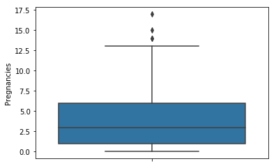

```python
sns.boxplot(y='Pregnancies',data=inp_data)
```

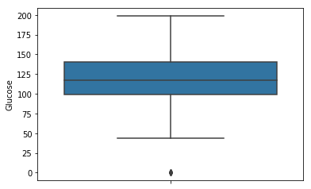

```python
sns.boxplot(y='Glucose',data=inp_data)
```

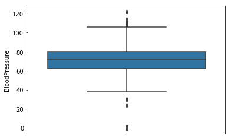

```python
sns.boxplot(y='BloodPressure',data=inp_data)
```

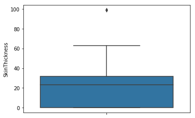

```python
sns.boxplot(y='SkinThickness',data=inp_data)
```

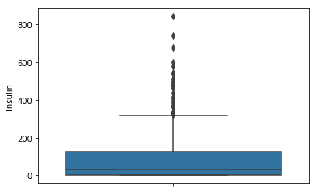

```python
sns.boxplot(y='Insulin',data=inp_data)
```

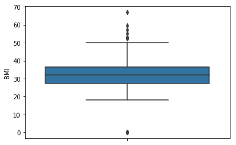

```python
sns.boxplot(y='BMI',data=inp_data)
```

# Find glucose columns with value 0

```python
inp_data[inp_data['Glucose'] == 0]
```

|  | Pregnancies | Glucose | BloodPressure | SkinThickness | Insulin | BMI | DiabetesPedigreeFunction | Age | Outcome |
| --- | --- | --- | --- | --- | --- | --- | --- | --- | --- |
| 75 | 1 | 0 | 48 | 20 | 0 | 24.7 | 0.140 | 22 | 0 |
| 182 | 1 | 0 | 74 | 20 | 23 | 27.7 | 0.299 | 21 | 0 |
| 342 | 1 | 0 | 68 | 35 | 0 | 32.0 | 0.389 | 22 | 0 |
| 349 | 5 | 0 | 80 | 32 | 0 | 41.0 | 0.346 | 37 | 1 |
| 502 | 6 | 0 | 68 | 41 | 0 | 39.0 | 0.727 | 41 | 1 |

# Since only 5 records are there with Glucose value 0 , we can drop those rows. The percentage is very less so we can do this.

```python
inp_data['Glucose'].replace(0,np.nan,inplace=True)
```

```python
inp_data=inp_data[np.isfinite(inp_data['Glucose'])]
```

```python
inp_data.info()
```

```
<class 'pandas.core.frame.DataFrame'>
Int64Index: 763 entries, 0 to 767
Data columns (total 9 columns):
Pregnancies                 763 non-null int64
Glucose                     763 non-null float64
BloodPressure               763 non-null int64
SkinThickness               763 non-null int64
Insulin                     763 non-null int64
BMI                         763 non-null float64
DiabetesPedigreeFunction    763 non-null float64
Age                         763 non-null int64
Outcome                     763 non-null int64
dtypes: float64(3), int64(6)
memory usage: 59.6 KB
```

Now we see that the no of rows is 763.

```python
inp_data[inp_data['Glucose']==0]
```

|  | Pregnancies | Glucose | BloodPressure | SkinThickness | Insulin | BMI | DiabetesPedigreeFunction | Age | Outcome |
| --- | --- | --- | --- | --- | --- | --- | --- | --- | --- |

# find BP column with value 0

```python
inp_data[inp_data['BloodPressure']==0]
```

|  | Pregnancies | Glucose | BloodPressure | SkinThickness | Insulin | BMI | DiabetesPedigreeFunction | Age | Outcome |
| --- | --- | --- | --- | --- | --- | --- | --- | --- | --- |
| 7 | 10 | 115.0 | 0 | 0 | 0 | 35.3 | 0.134 | 29 | 0 |
| 15 | 7 | 100.0 | 0 | 0 | 0 | 30.0 | 0.484 | 32 | 1 |
| 49 | 7 | 105.0 | 0 | 0 | 0 | 0.0 | 0.305 | 24 | 0 |
| 60 | 2 | 84.0 | 0 | 0 | 0 | 0.0 | 0.304 | 21 | 0 |
| 78 | 0 | 131.0 | 0 | 0 | 0 | 43.2 | 0.270 | 26 | 1 |
| 81 | 2 | 74.0 | 0 | 0 | 0 | 0.0 | 0.102 | 22 | 0 |
| 172 | 2 | 87.0 | 0 | 23 | 0 | 28.9 | 0.773 | 25 | 0 |
| 193 | 11 | 135.0 | 0 | 0 | 0 | 52.3 | 0.578 | 40 | 1 |
| 222 | 7 | 119.0 | 0 | 0 | 0 | 25.2 | 0.209 | 37 | 0 |
| 261 | 3 | 141.0 | 0 | 0 | 0 | 30.0 | 0.761 | 27 | 1 |
| 266 | 0 | 138.0 | 0 | 0 | 0 | 36.3 | 0.933 | 25 | 1 |
| 269 | 2 | 146.0 | 0 | 0 | 0 | 27.5 | 0.240 | 28 | 1 |
| 300 | 0 | 167.0 | 0 | 0 | 0 | 32.3 | 0.839 | 30 | 1 |
| 332 | 1 | 180.0 | 0 | 0 | 0 | 43.3 | 0.282 | 41 | 1 |
| 336 | 0 | 117.0 | 0 | 0 | 0 | 33.8 | 0.932 | 44 | 0 |
| 347 | 3 | 116.0 | 0 | 0 | 0 | 23.5 | 0.187 | 23 | 0 |
| 357 | 13 | 129.0 | 0 | 30 | 0 | 39.9 | 0.569 | 44 | 1 |
| 426 | 0 | 94.0 | 0 | 0 | 0 | 0.0 | 0.256 | 25 | 0 |
| 430 | 2 | 99.0 | 0 | 0 | 0 | 22.2 | 0.108 | 23 | 0 |
| 435 | 0 | 141.0 | 0 | 0 | 0 | 42.4 | 0.205 | 29 | 1 |
| 453 | 2 | 119.0 | 0 | 0 | 0 | 19.6 | 0.832 | 72 | 0 |
| 468 | 8 | 120.0 | 0 | 0 | 0 | 30.0 | 0.183 | 38 | 1 |
| 484 | 0 | 145.0 | 0 | 0 | 0 | 44.2 | 0.630 | 31 | 1 |
| 494 | 3 | 80.0 | 0 | 0 | 0 | 0.0 | 0.174 | 22 | 0 |
| 522 | 6 | 114.0 | 0 | 0 | 0 | 0.0 | 0.189 | 26 | 0 |
| 533 | 6 | 91.0 | 0 | 0 | 0 | 29.8 | 0.501 | 31 | 0 |
| 535 | 4 | 132.0 | 0 | 0 | 0 | 32.9 | 0.302 | 23 | 1 |
| 589 | 0 | 73.0 | 0 | 0 | 0 | 21.1 | 0.342 | 25 | 0 |
| 601 | 6 | 96.0 | 0 | 0 | 0 | 23.7 | 0.190 | 28 | 0 |
| 604 | 4 | 183.0 | 0 | 0 | 0 | 28.4 | 0.212 | 36 | 1 |
| 619 | 0 | 119.0 | 0 | 0 | 0 | 32.4 | 0.141 | 24 | 1 |
| 643 | 4 | 90.0 | 0 | 0 | 0 | 28.0 | 0.610 | 31 | 0 |
| 697 | 0 | 99.0 | 0 | 0 | 0 | 25.0 | 0.253 | 22 | 0 |
| 703 | 2 | 129.0 | 0 | 0 | 0 | 38.5 | 0.304 | 41 | 0 |
| 706 | 10 | 115.0 | 0 | 0 | 0 | 0.0 | 0.261 | 30 | 1 |

# Here, the mean and the median of the BP is almost same so we can replace '0' BP with mean of BP

```python
inp_data['BloodPressure'].replace(0,inp_data['BloodPressure'].mean(),inplace=True)
```

```python
inp_data[inp_data['BloodPressure']==0]
```

|  | Pregnancies | Glucose | BloodPressure | SkinThickness | Insulin | BMI | DiabetesPedigreeFunction | Age | Outcome |
| --- | --- | --- | --- | --- | --- | --- | --- | --- | --- |

# Find Skinthickness columns with value 0

```python
inp_data[inp_data['SkinThickness'] == 0]
```

|  | Pregnancies | Glucose | BloodPressure | SkinThickness | Insulin | BMI | DiabetesPedigreeFunction | Age | Outcome |
| --- | --- | --- | --- | --- | --- | --- | --- | --- | --- |
| 2 | 8 | 183.0 | 64.000000 | 0 | 0 | 23.3 | 0.672 | 32 | 1 |
| 5 | 5 | 116.0 | 74.000000 | 0 | 0 | 25.6 | 0.201 | 30 | 0 |
| 7 | 10 | 115.0 | 69.115334 | 0 | 0 | 35.3 | 0.134 | 29 | 0 |
| 9 | 8 | 125.0 | 96.000000 | 0 | 0 | 0.0 | 0.232 | 54 | 1 |
| 10 | 4 | 110.0 | 92.000000 | 0 | 0 | 37.6 | 0.191 | 30 | 0 |
| 11 | 10 | 168.0 | 74.000000 | 0 | 0 | 38.0 | 0.537 | 34 | 1 |
| 12 | 10 | 139.0 | 80.000000 | 0 | 0 | 27.1 | 1.441 | 57 | 0 |
| 15 | 7 | 100.0 | 69.115334 | 0 | 0 | 30.0 | 0.484 | 32 | 1 |
| 17 | 7 | 107.0 | 74.000000 | 0 | 0 | 29.6 | 0.254 | 31 | 1 |
| 21 | 8 | 99.0 | 84.000000 | 0 | 0 | 35.4 | 0.388 | 50 | 0 |
| 22 | 7 | 196.0 | 90.000000 | 0 | 0 | 39.8 | 0.451 | 41 | 1 |
| 26 | 7 | 147.0 | 76.000000 | 0 | 0 | 39.4 | 0.257 | 43 | 1 |
| 29 | 5 | 117.0 | 92.000000 | 0 | 0 | 34.1 | 0.337 | 38 | 0 |
| 33 | 6 | 92.0 | 92.000000 | 0 | 0 | 19.9 | 0.188 | 28 | 0 |
| 36 | 11 | 138.0 | 76.000000 | 0 | 0 | 33.2 | 0.420 | 35 | 0 |
| 41 | 7 | 133.0 | 84.000000 | 0 | 0 | 40.2 | 0.696 | 37 | 0 |
| 44 | 7 | 159.0 | 64.000000 | 0 | 0 | 27.4 | 0.294 | 40 | 0 |
| 46 | 1 | 146.0 | 56.000000 | 0 | 0 | 29.7 | 0.564 | 29 | 0 |
| 49 | 7 | 105.0 | 69.115334 | 0 | 0 | 0.0 | 0.305 | 24 | 0 |
| 58 | 0 | 146.0 | 82.000000 | 0 | 0 | 40.5 | 1.781 | 44 | 0 |
| 60 | 2 | 84.0 | 69.115334 | 0 | 0 | 0.0 | 0.304 | 21 | 0 |
| 61 | 8 | 133.0 | 72.000000 | 0 | 0 | 32.9 | 0.270 | 39 | 1 |
| 62 | 5 | 44.0 | 62.000000 | 0 | 0 | 25.0 | 0.587 | 36 | 0 |
| 64 | 7 | 114.0 | 66.000000 | 0 | 0 | 32.8 | 0.258 | 42 | 1 |
| 67 | 2 | 109.0 | 92.000000 | 0 | 0 | 42.7 | 0.845 | 54 | 0 |
| 72 | 13 | 126.0 | 90.000000 | 0 | 0 | 43.4 | 0.583 | 42 | 1 |
| 76 | 7 | 62.0 | 78.000000 | 0 | 0 | 32.6 | 0.391 | 41 | 0 |
| 78 | 0 | 131.0 | 69.115334 | 0 | 0 | 43.2 | 0.270 | 26 | 1 |
| 81 | 2 | 74.0 | 69.115334 | 0 | 0 | 0.0 | 0.102 | 22 | 0 |
| 84 | 5 | 137.0 | 108.000000 | 0 | 0 | 48.8 | 0.227 | 37 | 1 |
| ... | ... | ... | ... | ... | ... | ... | ... | ... | ... |
| 675 | 6 | 195.0 | 70.000000 | 0 | 0 | 30.9 | 0.328 | 31 | 1 |
| 676 | 9 | 156.0 | 86.000000 | 0 | 0 | 24.8 | 0.230 | 53 | 1 |
| 677 | 0 | 93.0 | 60.000000 | 0 | 0 | 35.3 | 0.263 | 25 | 0 |
| 678 | 3 | 121.0 | 52.000000 | 0 | 0 | 36.0 | 0.127 | 25 | 1 |
| 683 | 4 | 125.0 | 80.000000 | 0 | 0 | 32.3 | 0.536 | 27 | 1 |
| 684 | 5 | 136.0 | 82.000000 | 0 | 0 | 0.0 | 0.640 | 69 | 0 |
| 686 | 3 | 130.0 | 64.000000 | 0 | 0 | 23.1 | 0.314 | 22 | 0 |
| 690 | 8 | 107.0 | 80.000000 | 0 | 0 | 24.6 | 0.856 | 34 | 0 |
| 691 | 13 | 158.0 | 114.000000 | 0 | 0 | 42.3 | 0.257 | 44 | 1 |
| 694 | 2 | 90.0 | 60.000000 | 0 | 0 | 23.5 | 0.191 | 25 | 0 |
| 697 | 0 | 99.0 | 69.115334 | 0 | 0 | 25.0 | 0.253 | 22 | 0 |
| 699 | 4 | 118.0 | 70.000000 | 0 | 0 | 44.5 | 0.904 | 26 | 0 |
| 703 | 2 | 129.0 | 69.115334 | 0 | 0 | 38.5 | 0.304 | 41 | 0 |
| 706 | 10 | 115.0 | 69.115334 | 0 | 0 | 0.0 | 0.261 | 30 | 1 |
| 708 | 9 | 164.0 | 78.000000 | 0 | 0 | 32.8 | 0.148 | 45 | 1 |
| 714 | 3 | 102.0 | 74.000000 | 0 | 0 | 29.5 | 0.121 | 32 | 0 |
| 724 | 1 | 111.0 | 94.000000 | 0 | 0 | 32.8 | 0.265 | 45 | 0 |
| 728 | 2 | 175.0 | 88.000000 | 0 | 0 | 22.9 | 0.326 | 22 | 0 |
| 729 | 2 | 92.0 | 52.000000 | 0 | 0 | 30.1 | 0.141 | 22 | 0 |
| 731 | 8 | 120.0 | 86.000000 | 0 | 0 | 28.4 | 0.259 | 22 | 1 |
| 734 | 2 | 105.0 | 75.000000 | 0 | 0 | 23.3 | 0.560 | 53 | 0 |
| 739 | 1 | 102.0 | 74.000000 | 0 | 0 | 39.5 | 0.293 | 42 | 1 |
| 743 | 9 | 140.0 | 94.000000 | 0 | 0 | 32.7 | 0.734 | 45 | 1 |
| 749 | 6 | 162.0 | 62.000000 | 0 | 0 | 24.3 | 0.178 | 50 | 1 |
| 750 | 4 | 136.0 | 70.000000 | 0 | 0 | 31.2 | 1.182 | 22 | 1 |
| 757 | 0 | 123.0 | 72.000000 | 0 | 0 | 36.3 | 0.258 | 52 | 1 |
| 758 | 1 | 106.0 | 76.000000 | 0 | 0 | 37.5 | 0.197 | 26 | 0 |
| 759 | 6 | 190.0 | 92.000000 | 0 | 0 | 35.5 | 0.278 | 66 | 1 |
| 762 | 9 | 89.0 | 62.000000 | 0 | 0 | 22.5 | 0.142 | 33 | 0 |
| 766 | 1 | 126.0 | 60.000000 | 0 | 0 | 30.1 | 0.349 | 47 | 1 |

227 rows × 9 columns

# Here , both mean and the median of SkinThickness are almost same, so we can Replace skinthickness column with value as 0 to mean of that column

```python
inp_data['SkinThickness'].replace(0,inp_data['SkinThickness'].mean(),inplace=True)
```

```python
inp_data[inp_data['SkinThickness'] == 0]
```

|  | Pregnancies | Glucose | BloodPressure | SkinThickness | Insulin | BMI | DiabetesPedigreeFunction | Age | Outcome |
| --- | --- | --- | --- | --- | --- | --- | --- | --- | --- |

# Find insulin column with value 0

```python
inp_data[inp_data['Insulin'] == 0]
```

|  | Pregnancies | Glucose | BloodPressure | SkinThickness | Insulin | BMI | DiabetesPedigreeFunction | Age | Outcome |
| --- | --- | --- | --- | --- | --- | --- | --- | --- | --- |
| 0 | 6 | 148.0 | 72.000000 | 35.000000 | 0 | 33.6 | 0.627 | 50 | 1 |
| 1 | 1 | 85.0 | 66.000000 | 29.000000 | 0 | 26.6 | 0.351 | 31 | 0 |
| 2 | 8 | 183.0 | 64.000000 | 20.477064 | 0 | 23.3 | 0.672 | 32 | 1 |
| 5 | 5 | 116.0 | 74.000000 | 20.477064 | 0 | 25.6 | 0.201 | 30 | 0 |
| 7 | 10 | 115.0 | 69.115334 | 20.477064 | 0 | 35.3 | 0.134 | 29 | 0 |
| 9 | 8 | 125.0 | 96.000000 | 20.477064 | 0 | 0.0 | 0.232 | 54 | 1 |
| 10 | 4 | 110.0 | 92.000000 | 20.477064 | 0 | 37.6 | 0.191 | 30 | 0 |
| 11 | 10 | 168.0 | 74.000000 | 20.477064 | 0 | 38.0 | 0.537 | 34 | 1 |
| 12 | 10 | 139.0 | 80.000000 | 20.477064 | 0 | 27.1 | 1.441 | 57 | 0 |
| 15 | 7 | 100.0 | 69.115334 | 20.477064 | 0 | 30.0 | 0.484 | 32 | 1 |
| 17 | 7 | 107.0 | 74.000000 | 20.477064 | 0 | 29.6 | 0.254 | 31 | 1 |
| 21 | 8 | 99.0 | 84.000000 | 20.477064 | 0 | 35.4 | 0.388 | 50 | 0 |
| 22 | 7 | 196.0 | 90.000000 | 20.477064 | 0 | 39.8 | 0.451 | 41 | 1 |
| 23 | 9 | 119.0 | 80.000000 | 35.000000 | 0 | 29.0 | 0.263 | 29 | 1 |
| 26 | 7 | 147.0 | 76.000000 | 20.477064 | 0 | 39.4 | 0.257 | 43 | 1 |
| 29 | 5 | 117.0 | 92.000000 | 20.477064 | 0 | 34.1 | 0.337 | 38 | 0 |
| 30 | 5 | 109.0 | 75.000000 | 26.000000 | 0 | 36.0 | 0.546 | 60 | 0 |
| 33 | 6 | 92.0 | 92.000000 | 20.477064 | 0 | 19.9 | 0.188 | 28 | 0 |
| 34 | 10 | 122.0 | 78.000000 | 31.000000 | 0 | 27.6 | 0.512 | 45 | 0 |
| 36 | 11 | 138.0 | 76.000000 | 20.477064 | 0 | 33.2 | 0.420 | 35 | 0 |
| 37 | 9 | 102.0 | 76.000000 | 37.000000 | 0 | 32.9 | 0.665 | 46 | 1 |
| 38 | 2 | 90.0 | 68.000000 | 42.000000 | 0 | 38.2 | 0.503 | 27 | 1 |
| 41 | 7 | 133.0 | 84.000000 | 20.477064 | 0 | 40.2 | 0.696 | 37 | 0 |
| 42 | 7 | 106.0 | 92.000000 | 18.000000 | 0 | 22.7 | 0.235 | 48 | 0 |
| 44 | 7 | 159.0 | 64.000000 | 20.477064 | 0 | 27.4 | 0.294 | 40 | 0 |
| 45 | 0 | 180.0 | 66.000000 | 39.000000 | 0 | 42.0 | 1.893 | 25 | 1 |
| 46 | 1 | 146.0 | 56.000000 | 20.477064 | 0 | 29.7 | 0.564 | 29 | 0 |
| 47 | 2 | 71.0 | 70.000000 | 27.000000 | 0 | 28.0 | 0.586 | 22 | 0 |
| 48 | 7 | 103.0 | 66.000000 | 32.000000 | 0 | 39.1 | 0.344 | 31 | 1 |
| 49 | 7 | 105.0 | 69.115334 | 20.477064 | 0 | 0.0 | 0.305 | 24 | 0 |
| ... | ... | ... | ... | ... | ... | ... | ... | ... | ... |
| 712 | 10 | 129.0 | 62.000000 | 36.000000 | 0 | 41.2 | 0.441 | 38 | 1 |
| 714 | 3 | 102.0 | 74.000000 | 20.477064 | 0 | 29.5 | 0.121 | 32 | 0 |
| 717 | 10 | 94.0 | 72.000000 | 18.000000 | 0 | 23.1 | 0.595 | 56 | 0 |
| 719 | 5 | 97.0 | 76.000000 | 27.000000 | 0 | 35.6 | 0.378 | 52 | 1 |
| 720 | 4 | 83.0 | 86.000000 | 19.000000 | 0 | 29.3 | 0.317 | 34 | 0 |
| 724 | 1 | 111.0 | 94.000000 | 20.477064 | 0 | 32.8 | 0.265 | 45 | 0 |
| 725 | 4 | 112.0 | 78.000000 | 40.000000 | 0 | 39.4 | 0.236 | 38 | 0 |
| 727 | 0 | 141.0 | 84.000000 | 26.000000 | 0 | 32.4 | 0.433 | 22 | 0 |
| 728 | 2 | 175.0 | 88.000000 | 20.477064 | 0 | 22.9 | 0.326 | 22 | 0 |
| 729 | 2 | 92.0 | 52.000000 | 20.477064 | 0 | 30.1 | 0.141 | 22 | 0 |
| 731 | 8 | 120.0 | 86.000000 | 20.477064 | 0 | 28.4 | 0.259 | 22 | 1 |
| 734 | 2 | 105.0 | 75.000000 | 20.477064 | 0 | 23.3 | 0.560 | 53 | 0 |
| 735 | 4 | 95.0 | 60.000000 | 32.000000 | 0 | 35.4 | 0.284 | 28 | 0 |
| 737 | 8 | 65.0 | 72.000000 | 23.000000 | 0 | 32.0 | 0.600 | 42 | 0 |
| 739 | 1 | 102.0 | 74.000000 | 20.477064 | 0 | 39.5 | 0.293 | 42 | 1 |
| 743 | 9 | 140.0 | 94.000000 | 20.477064 | 0 | 32.7 | 0.734 | 45 | 1 |
| 746 | 1 | 147.0 | 94.000000 | 41.000000 | 0 | 49.3 | 0.358 | 27 | 1 |
| 749 | 6 | 162.0 | 62.000000 | 20.477064 | 0 | 24.3 | 0.178 | 50 | 1 |
| 750 | 4 | 136.0 | 70.000000 | 20.477064 | 0 | 31.2 | 1.182 | 22 | 1 |
| 752 | 3 | 108.0 | 62.000000 | 24.000000 | 0 | 26.0 | 0.223 | 25 | 0 |
| 754 | 8 | 154.0 | 78.000000 | 32.000000 | 0 | 32.4 | 0.443 | 45 | 1 |
| 756 | 7 | 137.0 | 90.000000 | 41.000000 | 0 | 32.0 | 0.391 | 39 | 0 |
| 757 | 0 | 123.0 | 72.000000 | 20.477064 | 0 | 36.3 | 0.258 | 52 | 1 |
| 758 | 1 | 106.0 | 76.000000 | 20.477064 | 0 | 37.5 | 0.197 | 26 | 0 |
| 759 | 6 | 190.0 | 92.000000 | 20.477064 | 0 | 35.5 | 0.278 | 66 | 1 |
| 761 | 9 | 170.0 | 74.000000 | 31.000000 | 0 | 44.0 | 0.403 | 43 | 1 |
| 762 | 9 | 89.0 | 62.000000 | 20.477064 | 0 | 22.5 | 0.142 | 33 | 0 |
| 764 | 2 | 122.0 | 70.000000 | 27.000000 | 0 | 36.8 | 0.340 | 27 | 0 |
| 766 | 1 | 126.0 | 60.000000 | 20.477064 | 0 | 30.1 | 0.349 | 47 | 1 |
| 767 | 1 | 93.0 | 70.000000 | 31.000000 | 0 | 30.4 | 0.315 | 23 | 0 |

370 rows × 9 columns

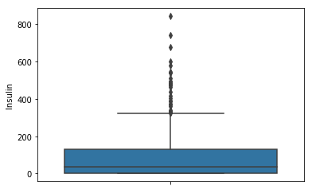

```python
sns.boxplot(y='Insulin',data=inp_data)
```

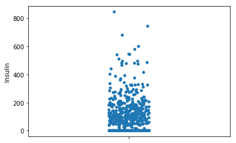

```python
sns.stripplot(y='Insulin',data=inp_data,jitter=True)
```

# Here we see that the mean and the median of Insulin column are very different from each other, so we cannot use mean to replace 0 value.

# Most of the values are between 0 and 200. So we can use 100 which is the range of the two values .

We can replace the 0 value with the value 100.

```python
inp_data['Insulin'].replace(0,100,inplace=True)
```

```python
inp_data[inp_data['Insulin'] == 0]
```

|  | Pregnancies | Glucose | BloodPressure | SkinThickness | Insulin | BMI | DiabetesPedigreeFunction | Age | Outcome |
| --- | --- | --- | --- | --- | --- | --- | --- | --- | --- |

# since both mean and the median of BMI column are almost similar, we can replace 0 with mean

```python
inp_data['BMI'].replace(0,inp_data['BMI'].mean(),inplace=True)
```

```python
inp_data[inp_data['BMI']==0]
```

|  | Pregnancies | Glucose | BloodPressure | SkinThickness | Insulin | BMI | DiabetesPedigreeFunction | Age | Outcome |
| --- | --- | --- | --- | --- | --- | --- | --- | --- | --- |

# After Data Preprocessing,

```python
inp_data.describe()
```

|  | Pregnancies | Glucose | BloodPressure | SkinThickness | Insulin | BMI | DiabetesPedigreeFunction | Age | Outcome |
| --- | --- | --- | --- | --- | --- | --- | --- | --- | --- |
| count | 763.000000 | 763.000000 | 763.000000 | 763.000000 | 763.000000 | 763.000000 | 763.000000 | 763.000000 | 763.000000 |
| mean | 3.851900 | 121.686763 | 72.285762 | 26.569192 | 128.785059 | 32.447909 | 0.472477 | 33.271298 | 0.348624 |
| std | 3.374729 | 30.535641 | 12.118289 | 9.647116 | 89.632677 | 6.878959 | 0.331963 | 11.772161 | 0.476847 |
| min | 0.000000 | 44.000000 | 24.000000 | 7.000000 | 14.000000 | 18.200000 | 0.078000 | 21.000000 | 0.000000 |
| 25% | 1.000000 | 99.000000 | 64.000000 | 20.477064 | 100.000000 | 27.500000 | 0.243500 | 24.000000 | 0.000000 |
| 50% | 3.000000 | 117.000000 | 72.000000 | 23.000000 | 100.000000 | 32.000000 | 0.374000 | 29.000000 | 0.000000 |
| 75% | 6.000000 | 141.000000 | 80.000000 | 32.000000 | 128.500000 | 36.550000 | 0.626500 | 41.000000 | 1.000000 |
| max | 17.000000 | 199.000000 | 122.000000 | 99.000000 | 846.000000 | 67.100000 | 2.420000 | 81.000000 | 1.000000 |

# Plotting histogram of all the columns

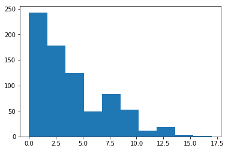

```python
plt.hist(inp_data['Pregnancies'])
```

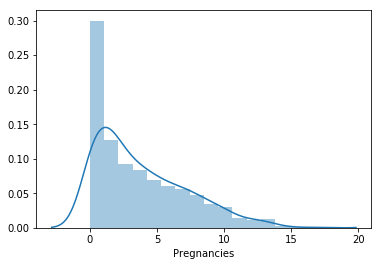

```python
sns.distplot(inp_data['Pregnancies'])
```

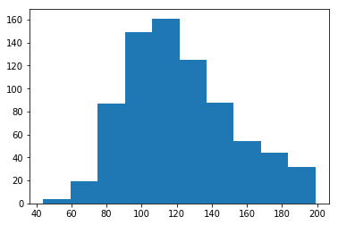

```python
plt.hist(inp_data['Glucose'])
```

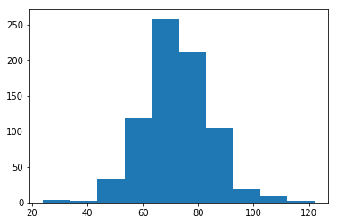

```python
plt.hist(inp_data['BloodPressure'])
```

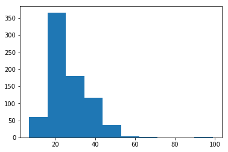

```python
plt.hist(inp_data['SkinThickness'])
```

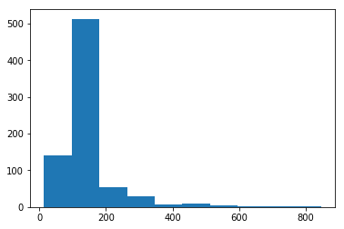

```python
plt.hist(inp_data['Insulin'])
```

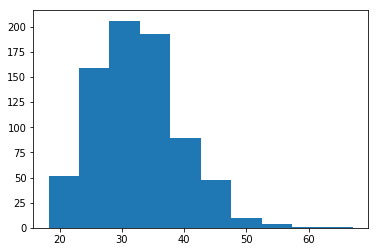

```python
plt.hist(inp_data['BMI'])
```

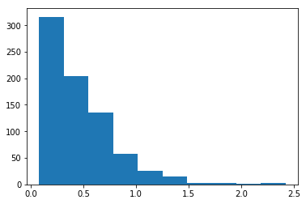

```python
plt.hist(inp_data['DiabetesPedigreeFunction'])
```

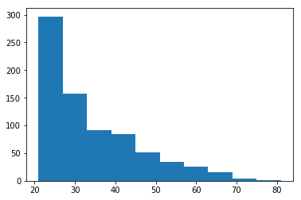

```python
plt.hist(inp_data['Age'])
```

# Using Facegrid finding histogram of each column with Outcome = 0 and 1 cases :

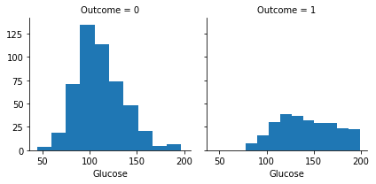

```python
a=sns.FacetGrid(inp_data,col='Outcome')
a.map(plt.hist,'Glucose')
```

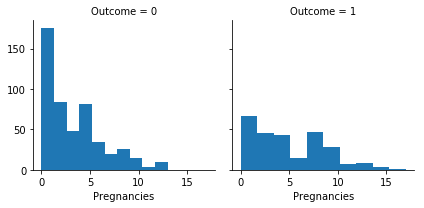

```python
a=sns.FacetGrid(inp_data,col='Outcome')
a.map(plt.hist,'Pregnancies')
```

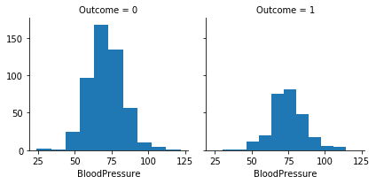

```python
a=sns.FacetGrid(inp_data,col='Outcome')
a.map(plt.hist,'BloodPressure')
```

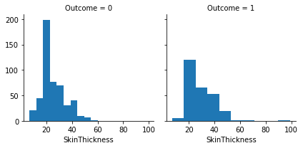

```python
a=sns.FacetGrid(inp_data,col='Outcome')
a.map(plt.hist,'SkinThickness')
```

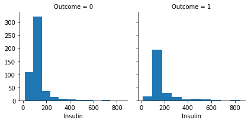

```python
a=sns.FacetGrid(inp_data,col='Outcome')
a.map(plt.hist,'Insulin')
```

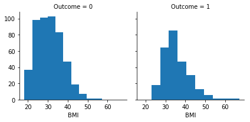

```python
a=sns.FacetGrid(inp_data,col='Outcome')
a.map(plt.hist,'BMI')
```

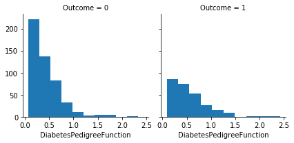

```python
a=sns.FacetGrid(inp_data,col='Outcome')
a.map(plt.hist,'DiabetesPedigreeFunction')
```

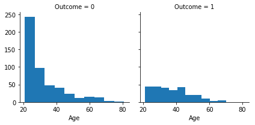

```python
a=sns.FacetGrid(inp_data,col='Outcome')
a.map(plt.hist,'Age')
```

# From the above histogram ploted for Outcome=0 and 1, we infer that,

```
    People with Glucose level less than 80 are less prone to diabetes.
    People with glucose range 150 to 200 are more prone to diabetes.
    The people with insulin value 100 has a partial chance of getting diabetes.But we also see that people with insulin value 100 are more in the non-diabeteic group.
    People with BMI range of 35 has a greater possiblity of getting diabetets.
    Peoplw with BMI less than 22 are less prone to diabetes
```

# Count plot for outcome

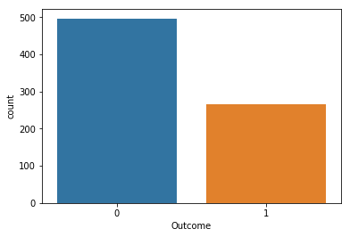

```python
sns.countplot(x='Outcome',data=inp_data)
```

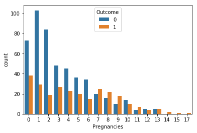

```python
sns.countplot(x='Pregnancies',data=inp_data,hue='Outcome')
```

# Using Boxplot with categorical variable

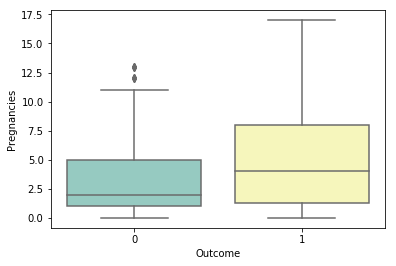

```python
sns.boxplot(x='Outcome',y='Pregnancies',data=inp_data,palette='Set3')
```

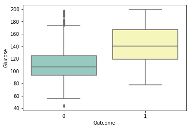

```python
sns.boxplot(x='Outcome',y='Glucose',data=inp_data,palette='Set3')
```

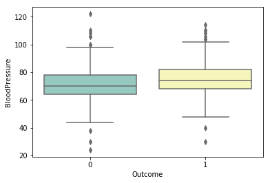

```python
sns.boxplot(x='Outcome',y='BloodPressure',data=inp_data,palette='Set3')
```

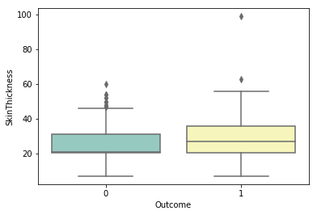

```python
sns.boxplot(x='Outcome',y='SkinThickness',data=inp_data,palette='Set3')
```

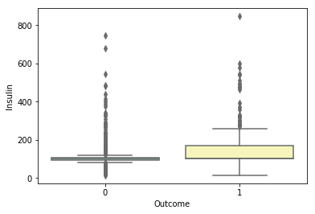

```python
sns.boxplot(x='Outcome',y='Insulin',data=inp_data,palette='Set3')
```

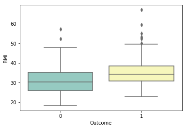

```python
sns.boxplot(x='Outcome',y='BMI',data=inp_data,palette='Set3')
```

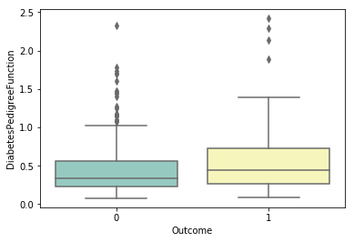

```python
sns.boxplot(x='Outcome',y='DiabetesPedigreeFunction',data=inp_data,palette='Set3')
```

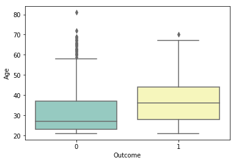

```python
sns.boxplot(x='Outcome',y='Age',data=inp_data,palette='Set3')
```

# From the above box plot observations, we see that the "Outcome column somewhat depends on the columns-- Glucose,BMI and Age"